# FQ and R per card - Gi’s Dataset

After seeing the effect above, I got curious to see how would be these associations per card! In the graph below we can see the association between FQ per number of the response (Rn_card) per Card. Each graph represent the correlation in the specific Card. See below.

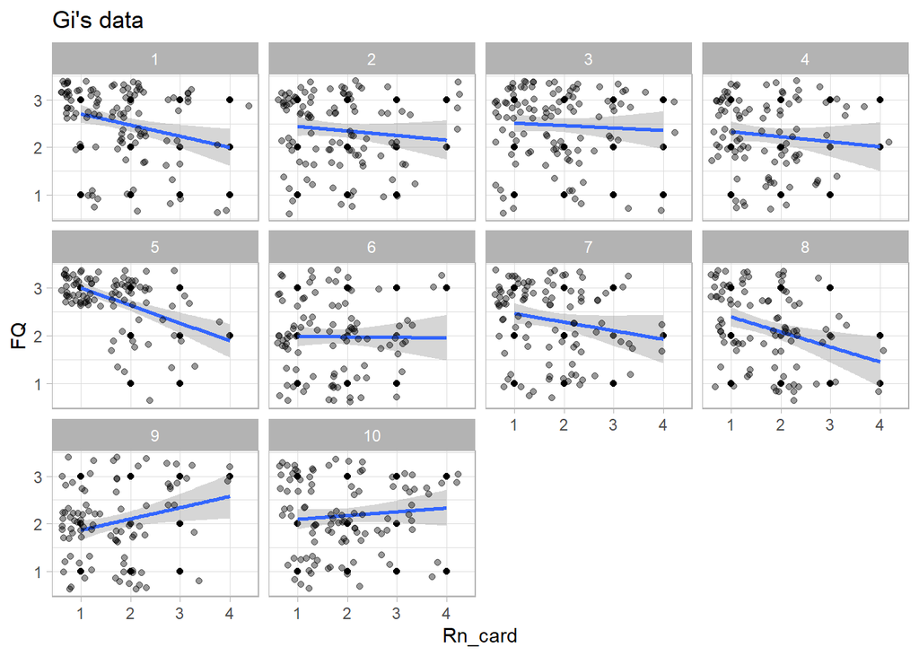

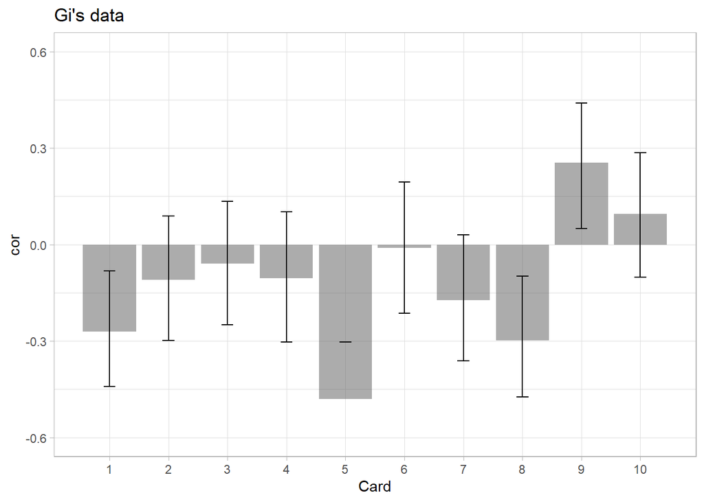

| Card | cor | CI_min | CI_max | p_value |
| --- | --- | --- | --- | --- |
| I | -0.27 | -0.44 | -0.08 | 0.01 |
| II | -0.11 | -0.30 | 0.09 | 0.28 |
| III | -0.06 | -0.25 | 0.13 | 0.55 |
| IV | -0.10 | -0.30 | 0.10 | 0.32 |
| V | -0.48 | -0.63 | -0.30 | 0.00 |
| VI | -0.01 | -0.21 | 0.19 | 0.92 |
| VII | -0.17 | -0.36 | 0.03 | 0.09 |
| VIII | -0.30 | -0.47 | -0.10 | 0.00 |
| IX | 0.25 | 0.05 | 0.44 | 0.02 |
| X | 0.10 | -0.10 | 0.29 | 0.34 |

# Filtering out FQu (FQ == u)

```r
data_filtered <- data %>% filter(FQ != 2)
```

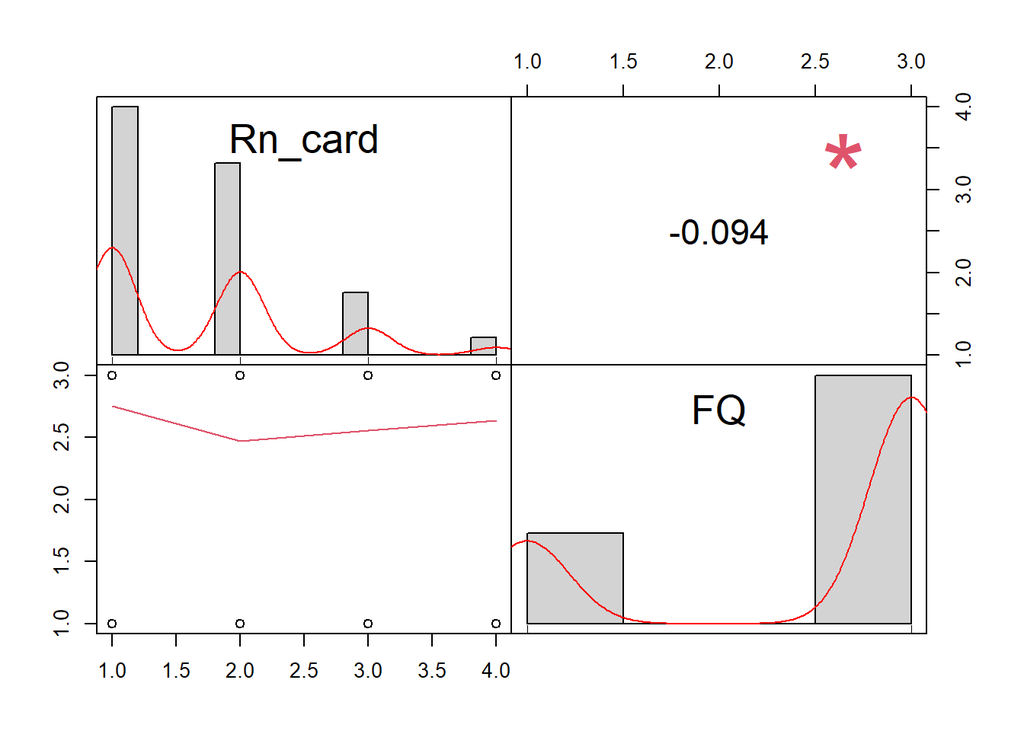

This is the result from Gi dataset, we observed a correlation with *r* = -.09, *p* = .017 , 95%CI[-.17, -.02]

From the scatterplot above, is hard to tell how the association really looks like, because most of the dots are on top of the others, so below, we can see a new scatterplot, presenting the same information as above but dispersing the dots a bit so we can better see the really amount of dots in each quadrant. The shadowy area around the regression line shows the CI.

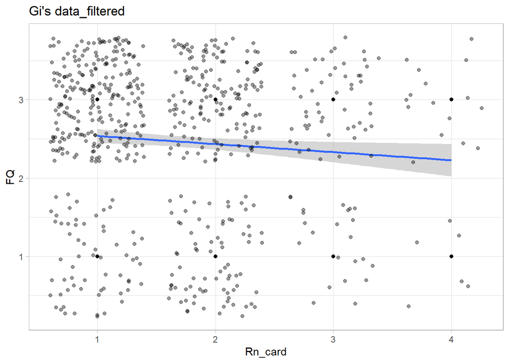

This way we can see that the association is indeed low. However, it is negative, which is in the expected direction.

After seeing the effect above, I got curious to see how would be these associations per card! In the graph below we can see the association between FQ per number of the response (Rn_card) per Card. Each graph represent the correlation in the specific Card. See below.

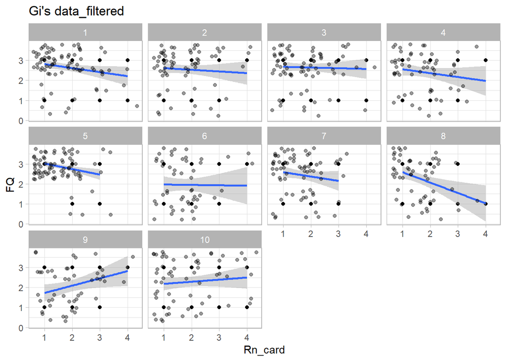

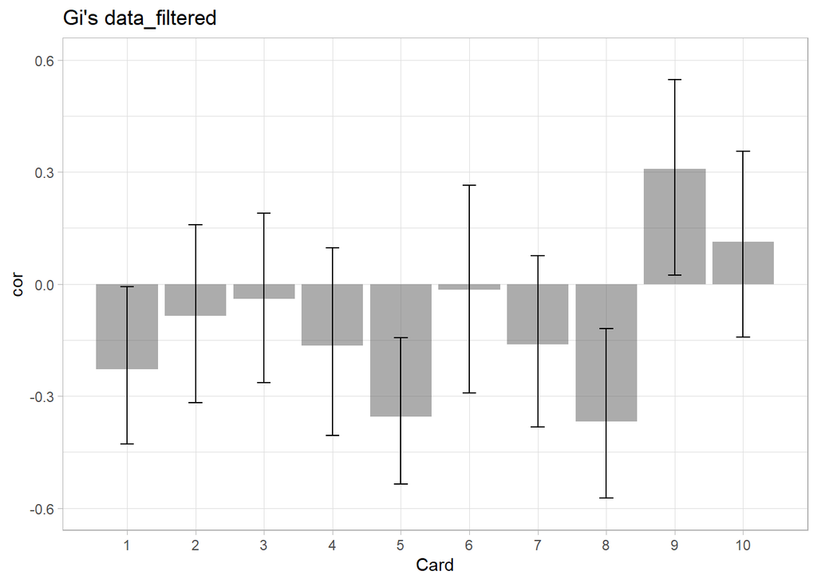

| Card | cor | CI_min | CI_max | p_value |
| --- | --- | --- | --- | --- |
| I | -0.23 | -0.43 | -0.01 | 0.04 |
| II | -0.08 | -0.32 | 0.16 | 0.49 |
| III | -0.04 | -0.26 | 0.19 | 0.74 |
| IV | -0.17 | -0.41 | 0.10 | 0.21 |
| V | -0.36 | -0.54 | -0.14 | 0.00 |
| VI | -0.01 | -0.29 | 0.26 | 0.92 |
| VII | -0.16 | -0.38 | 0.08 | 0.18 |
| VIII | -0.37 | -0.57 | -0.12 | 0.00 |
| IX | 0.31 | 0.02 | 0.55 | 0.03 |
| X | 0.11 | -0.14 | 0.36 | 0.38 |

# Using FQ2 (FQo and FQu == 3, FQ- == 1)

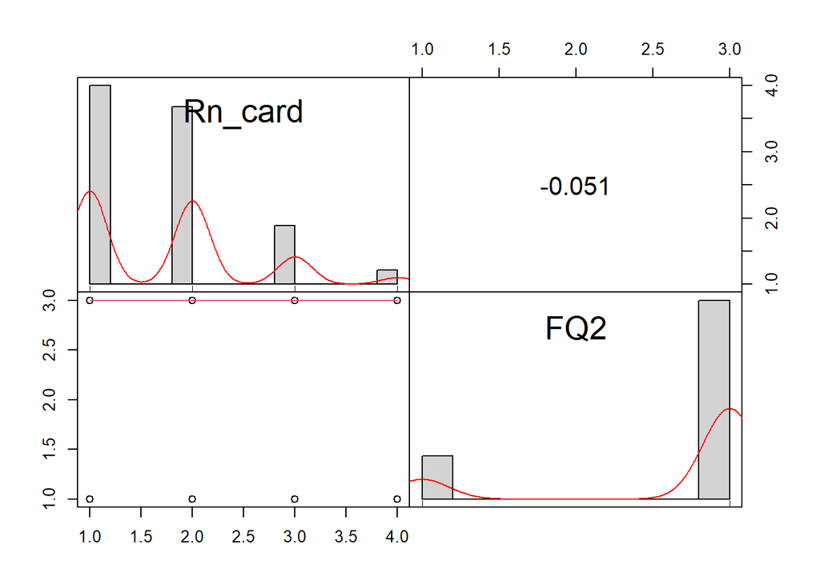

From the scatterplot above, is hard to tell how the association really looks like, because most of the dots are on top of the others, so below, we can see a new scatterplot, presenting the same information as above but dispersing the dots a bit so we can better see the really amount of dots in each quadrant. The shadowy area around the regression line shows the CI.

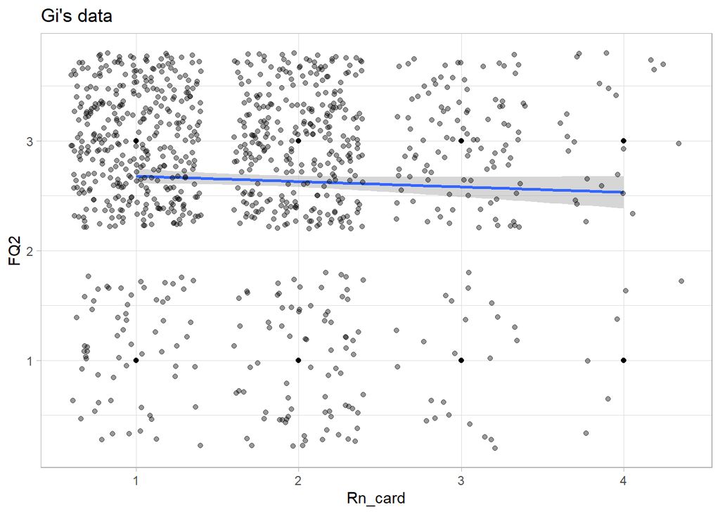

This way we can see that the association is indeed low. However, it is negative, which is in the expected direction.

After seeing the effect above, I got curious to see how would be these associations per card! In the graph below we can see the association between FQ2 per number of the response (Rn_card) per Card. Each graph represent the correlation in the specific Card. See below.

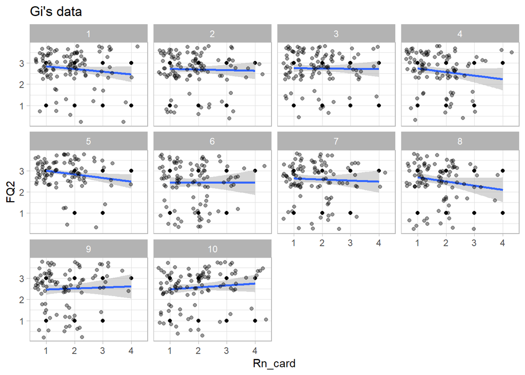

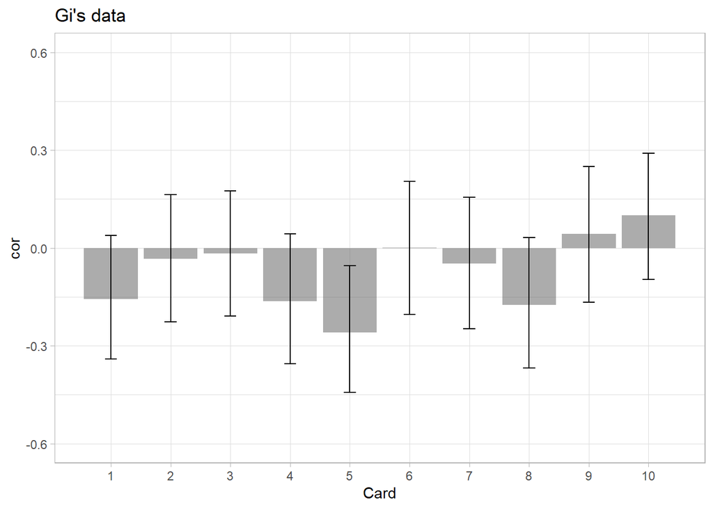

| Card | cor | CI_min | CI_max | p_value |
| --- | --- | --- | --- | --- |
| I | -0.16 | -0.34 | 0.04 | 0.11 |
| II | -0.03 | -0.23 | 0.16 | 0.75 |
| III | -0.02 | -0.21 | 0.18 | 0.86 |
| IV | -0.16 | -0.36 | 0.04 | 0.12 |
| V | -0.26 | -0.44 | -0.05 | 0.01 |
| VI | 0.00 | -0.20 | 0.20 | 1.00 |
| VII | -0.05 | -0.25 | 0.15 | 0.64 |
| VIII | -0.18 | -0.37 | 0.03 | 0.10 |
| IX | 0.04 | -0.17 | 0.25 | 0.68 |
| X | 0.10 | -0.10 | 0.29 | 0.32 |